# Behavioral econometrics

## Example dataset

```r
library(foreign)
library(ggplot2)
Hey2001<- read.csv("../2021ECON5820/Hey2001.csv")

knitr::kable(head(Hey2001))
```

| id | t | q1 | q2 | q3 | q4 | p1 | p2 | p3 | p4 | y |
| --- | --- | --- | --- | --- | --- | --- | --- | --- | --- | --- |
| 1 | 1 | 0 | 0 | 0.875 | 0.125 | 0 | 0.125 | 0.000 | 0.875 | 0 |
| 1 | 2 | 0 | 0 | 0.875 | 0.125 | 0 | 0.125 | 0.000 | 0.875 | 0 |
| 1 | 3 | 0 | 0 | 0.875 | 0.125 | 0 | 0.125 | 0.500 | 0.375 | 1 |
| 1 | 4 | 0 | 0 | 0.875 | 0.125 | 0 | 0.375 | 0.000 | 0.625 | 0 |
| 1 | 5 | 0 | 0 | 0.875 | 0.125 | 0 | 0.375 | 0.125 | 0.500 | 1 |
| 1 | 6 | 0 | 0 | 0.875 | 0.125 | 0 | 0.375 | 0.250 | 0.375 | 1 |

- decisions over 2 lotteries. $p$ or $q$
- $y=1$ iff $i$ chooses the q-lottery in decision $t$
- prizes: 0, 50, 100, 150 pounds

## Risk neutral

Maximization problem
$$\max_l\{E[u(X\mid l)]\}$$

Probabilistic choice function. Given choice set $\mathbb A$ (softmax)
$$\Pr\left(l\right)\propto \exp\left(\lambda E[u(x)\mid l]\right)$$

- As the utility of one action increases, I am more likely to take it.
- Interpretations
  - I make mistakes, but I recognize big payoff differences better than small ones
  - There is a random component to my utility (observed by the decision-maker but not econometrician)
  - There is a component of my utility that is not modeled well by $E[u(x)\mid l]$

Since we have only 2 choices, this becomes:

$$\begin{aligned}
\Pr(y=1\mid p,q)&=\frac{\exp(\lambda E[u(x)\mid q])}{\exp(\lambda E[u(x)\mid q])+\exp(\lambda E[u(x)\mid p])}\\
&=\left(1+\exp\left(\lambda\left(E[u(x)\mid p]-E[u(x)\mid q]\right)\right)\right)^{-1}
\end{aligned}$$

log-likeihood function:
$$\mathcal L(\theta)=\sum_{t=1}^T\Pr(y_t\mid p_y,q_t)$$

For risk-neutral: $u(x)=x$

```r
library(dplyr)
D<-(Hey2001
    %>% mutate(EVq = 0*q1+50*q2+100*q3+150*q4,
               EVp = 0*p1+50*p2+100*p3+150*p4
    )
    %>% mutate(DEV = EVq-EVp)
)
head(D)
```

```
##   id t q1 q2    q3    q4 p1    p2    p3    p4 y    EVq    EVp    DEV
## 1  1 1  0  0 0.875 0.125  0 0.125 0.000 0.875 0 106.25 137.50 -31.25
## 2  1 2  0  0 0.875 0.125  0 0.125 0.000 0.875 0 106.25 137.50 -31.25
## 3  1 3  0  0 0.875 0.125  0 0.125 0.500 0.375 1 106.25 112.50  -6.25
## 4  1 4  0  0 0.875 0.125  0 0.375 0.000 0.625 0 106.25 112.50  -6.25
## 5  1 5  0  0 0.875 0.125  0 0.375 0.125 0.500 1 106.25 106.25   0.00
## 6  1 6  0  0 0.875 0.125  0 0.375 0.250 0.375 1 106.25 100.00   6.25
```

Define and maximize likelihood:

```r
LL<-function(lambda,DEV,y) {
  # somthing in here to change DEV to DEU
  sum(-log(1+exp((-1)^y*lambda*DEV)))
}

LL(1,D$DEV,D$y)
```

```
## [1] -78116.31
```

```r
lambdaHat<- optimize(function(x) {-LL(x,D$DEV,D$y)}, c(0, 1))

print(lambdaHat)
```

```
## $minimum
## [1] 0.06112392
##
## $objective
## [1] 15170.62
```

## Estimate a $\lambda_i$ for every subject (split by ID)

```r
lambdaHat<-function(DEV,y) {
  optimize(function(x) {-LL(x,DEV,y)}, c(0, 1))$minimum
}

print(lambdaHat(D$DEV,D$y))
```

```
## [1] 0.06112392
```

```r
LambdaHatEstimates<-(D
                     %>% group_by(id)
                     %>% summarize(lhat = lambdaHat(DEV,y)))
LambdaHatEstimates %>% head() %>% knitr::kable()
```

| id | lhat |
| --- | --- |
| 1 | 0.0293029 |
| 2 | 0.0461682 |
| 3 | 0.0412640 |
| 4 | 0.1111173 |
| 5 | 0.0374135 |
| 6 | 0.1656475 |

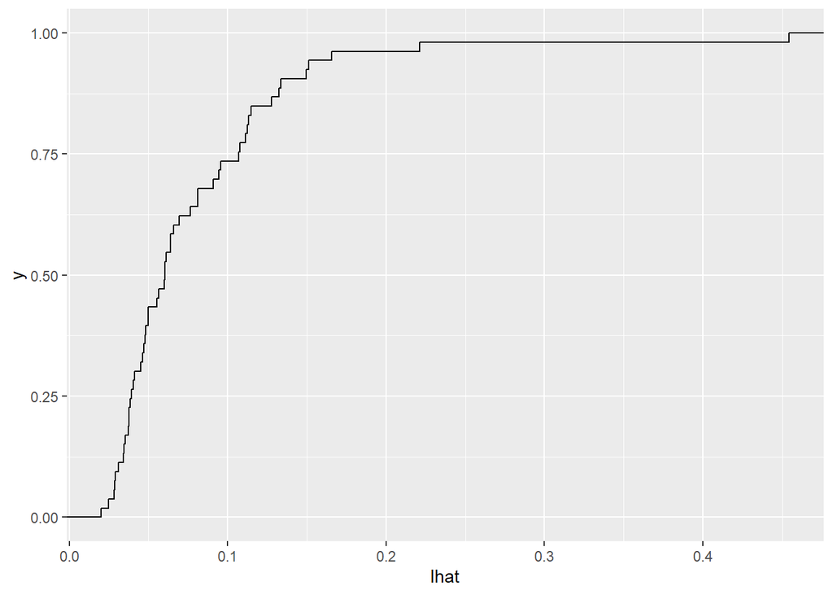

```r
(
  ggplot(LambdaHatEstimates,aes(x=lhat))
  +stat_ecdf()
)
```

In context:
$$\Pr(\text{chooses y to max DEV})=(1+\exp(-\lambda |\mathrm{DEV}|)^{-1}$$
on average, a subject will choose the “right” action with probability
$$\frac{1}{T}\sum_{t=1}^T(1+\exp(-\lambda |\mathrm{DEV}_t|)^{-1}$$

```r
LogitResponse<-function(l,DEV) {
  mean(1/(1+exp(-l*abs(DEV))))
}
EVloss<-function(l,DEV) {
  p<-(1/(1+exp(-l*abs(DEV))))

  mean(p*0+(1-p)*abs(DEV))
}


LambdaHatEstimates<-(D
  %>% left_join(LambdaHatEstimates,by="id")
  %>% group_by(id)
  %>% summarize(PrHat = LogitResponse(lhat,DEV),
                EVloss = EVloss(lhat,DEV),
                lhat = mean(lhat))
)
LambdaHatEstimates %>% head() %>% knitr::kable()
```

| id | PrHat | EVloss | lhat |
| --- | --- | --- | --- |
| 1 | 0.6032170 | 4.663298 | 0.0293029 |
| 2 | 0.6500962 | 3.537870 | 0.0461682 |
| 3 | 0.6374532 | 3.826159 | 0.0412640 |
| 4 | 0.7619261 | 1.450055 | 0.1111173 |
| 5 | 0.6269719 | 4.073668 | 0.0374135 |
| 6 | 0.8097907 | 0.812481 | 0.1656475 |

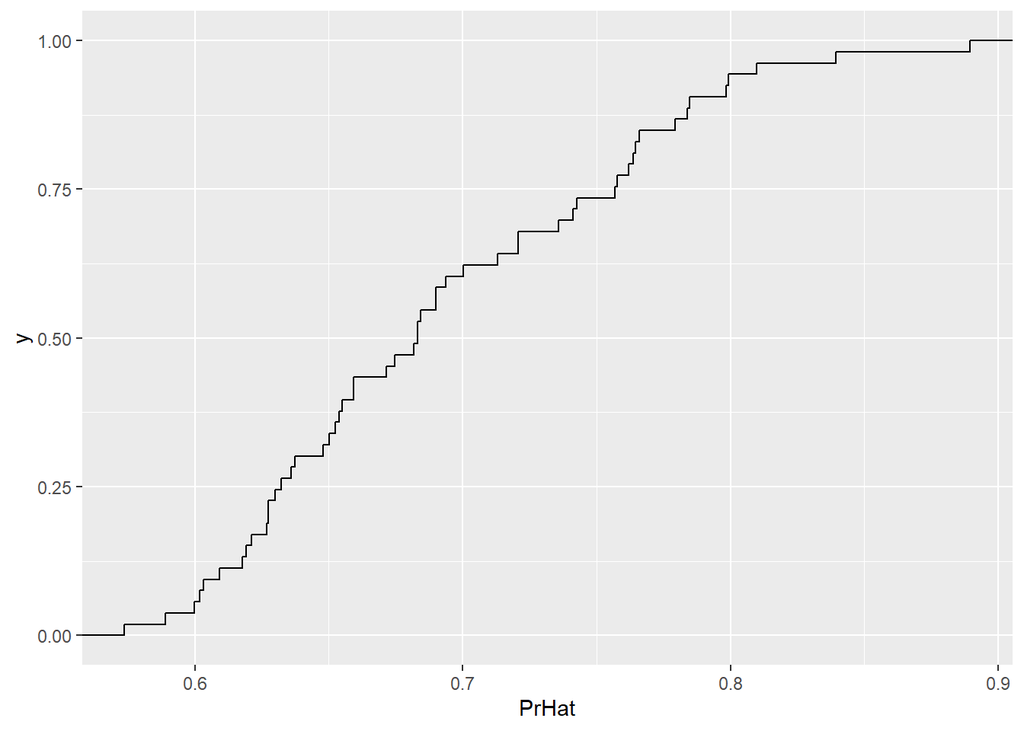

```r
(
  ggplot(LambdaHatEstimates,aes(x=PrHat))+stat_ecdf()
)
```

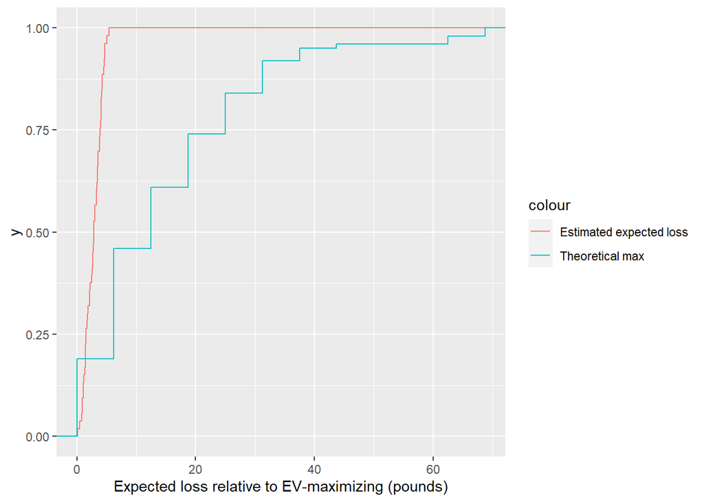

```r
(
  ggplot()
  +stat_ecdf(data=LambdaHatEstimates,aes(x=EVloss,color="Estimated expected loss"))
  +stat_ecdf(data=D %>% filter(id==1),aes(x=abs(DEV),color="Theoretical max"))
  +xlab("Expected loss relative to EV-maximizing (pounds)")
)
```

## Adding in risk aversion

Expected utility in vector form:
$$\begin{aligned}
u(x)&=(u(x_1),u(x_2),\ldots)\\
p&=(p_1,p_2,p_3,p_4)\\
q&=(q_1,q_2,q_3,q_4)\\
E[u(X)\mid p]&=p^\top u(x)\\
E[u(X)\mid q]&=q^\top u(x)\\
DEU(u,p,q)&=(q-p)^\top u(x)
\end{aligned}$$

```r
prizes<-c(0,50,100,150)

LL<-function(params,p,q,y) {
  r<-exp(params[1])
  lambda<-exp(params[2])

  Ux<-as.matrix(prizes^r)


  EUq<-as.matrix(q) %*% Ux
  EUp<-as.matrix(p) %*% Ux


  DEU<-EUq-EUp


  sum(-log(1+exp((-1)^as.matrix(y)*lambda*DEU)))
}

p<-D%>% filter(id==1) %>% dplyr::select(p1:p4)
q<-D%>% filter(id==1) %>% dplyr::select(q1:q4)
y<-D %>% filter(id==1) %>% dplyr::select(y)


EUHat<-function(p,q,y) {
  exp(optim(c(log(0.5),log(0.7)),function(x) {-LL(x,p,q,y)})$par)
}

Estimates<-(D
                     %>% group_by(id)
                     %>% summarize(rhat = EUHat(p,q,y)[1],
                                   lhat = EUHat(p,q,y)[2])
            )
```

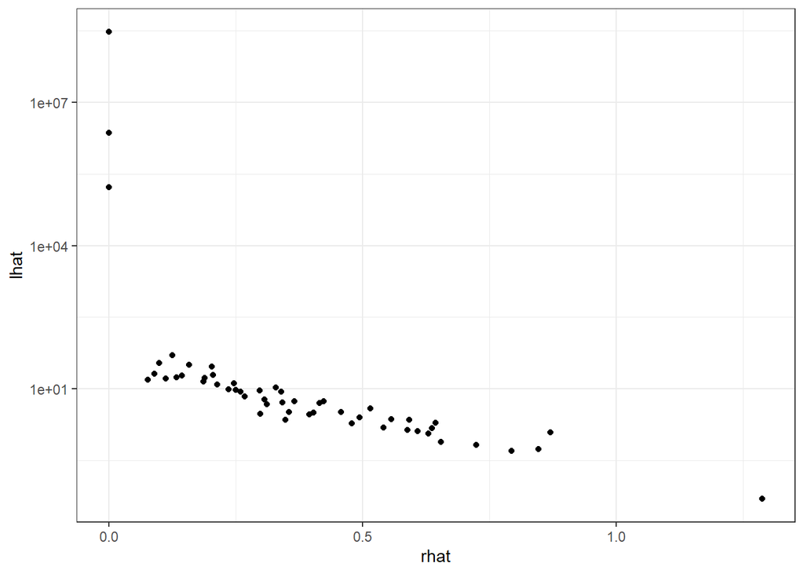

```r
#Estimates %>% head() %>% knitr::kable()

library(latex2exp)
(
  ggplot(Estimates,aes(x=rhat,y=lhat))+geom_point()
  +theme_bw()
  #+xlab(TeX("$\\hat r$"))+ylab(TeX("$\\hat\\lambda$"))
   +ylim(c(0,exp(10)))
  +scale_y_continuous(trans="log10")
)
```

## Certainty equivalents:

Lottery induced by behaving according to parameters $r$ and $\lambda$
$$\begin{aligned}
\Pr(y_t=1\mid r,\lambda)&=(1+\exp(\lambda DEU_t(r)))^{-1}
\end{aligned}$$
Induced lottery for choice $t$:
$$q_t\Pr(y_t=1\mid r,\lambda)+p_t\left(1-\Pr(y_t=1\mid r,\lambda)\right)$$
what is the lottery of the entire experiment?
$$L=\frac{1}{T}\sum_{i=1}^T\left(q_t\Pr(y_t=1\mid r,\lambda)+p_t\left(1-\Pr(y_t=1\mid r,\lambda)\right)\right)$$
Expected utility of experiment:
$$EU(\text{expt})=L^\top u(x)$$
Certainty equivalent of an experiment:
$$CE(\text{expt})=u^{-1}\left(EU(\text{expt})\right)$$

From here, we can calculate:

- How much is the experiment worth to someone who behaves according to $(r,\lambda)$?
- How much *could* it be worth if we shut down the noise (i.e. $\lambda\to\infty$)?
- How much was the experiment worth based on their actual choices?

> Bland, J.R., 2020. Measuring and comparing two kinds of rationalizable opportunity cost in mixture models. Games, 11(1), p.1.

> Alekseev, Aleksandr, Glenn W. Harrison, Morten Lau, and Don Ross. “[Deciphering the noise: the welfare costs of noisy behavior](https://cear.gsu.edu/files/2018/03/WP_2018_01_Deciphering-the-Noise-The-Welfare-Costs-of-Noisy-Behavior_2019_0326.pdf).” (2019).